# Lecture 413

2021-11-30

## Hierarchical and density-based clustering

## Recap

**Prev**: Centroid-based clustering

- K-means
- Fuzzy c-means
- Geodemographic classification

**Now**: Hierarchical and density-based clustering

- Hierarchical
- Mixed
- Density-based

## Example

Can we automatically identify the two groups visible in the scatterplot, without any previous knowledge of the groups?

```r
penguins_norm <-
  palmerpenguins::penguins %>%
  dplyr::filter(
    species %in%
      c("Adelie", "Gentoo")
  ) %>%
  dplyr::filter(
    !is.na(body_mass_g) |
      !is.na(bill_depth_mm)
  ) %>%
  dplyr::mutate(
    body_mass_norm =
      scale(body_mass_g),
    bill_depth_norm =
      scale(bill_depth_mm)
  )
```

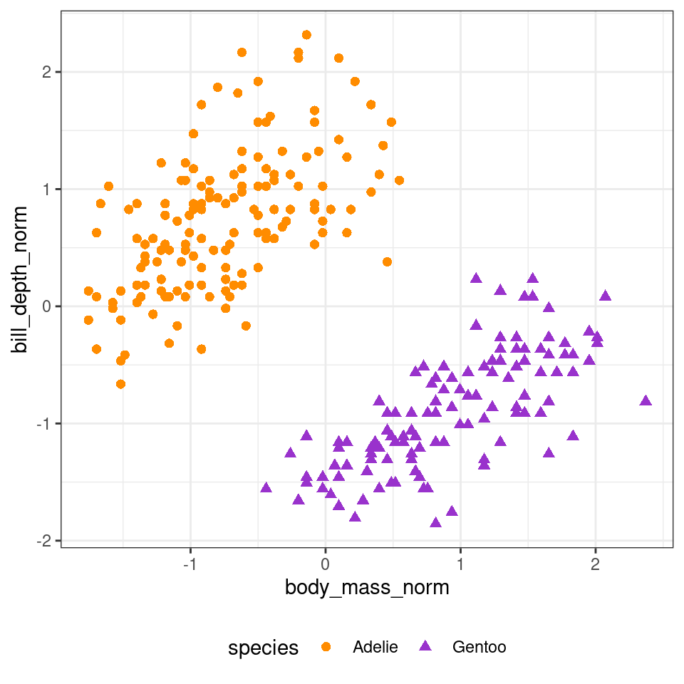

## Hierarchical clustering

Bottom-up approach

- rather than splitting objects into clusters
- aggregate from single objects upwards

**Algorithm**:

- each object is initialised as it’s own cluster
- then repeat
  - join the two most similar clusters
    - based on a distance-based metric
    - e.g., Ward’s (1963) approach is based on variance
  - until only one single cluster is achieved

**Limitation**: computationally expensive

## stats::hclust

```r
penguins_hclust_result <-
  penguins_norm %>%
  dplyr::select(
    body_mass_norm,
    bill_depth_norm
  ) %>%
  # Calculate distance matrix
  stats::dist(method="euclidean") %>%
  # Cluster data
  stats::hclust(method="ward.D2")

penguins_bm_bd_hclust <- penguins_norm %>%
  tibble::add_column(
    bm_bd_hclust = stats::cutree(
      penguins_hclust_result,
      k = 2
    )
  )
```

## clustering tree

Generates a clustering tree (dendrogram), which can then be *“cut”* at the desired height

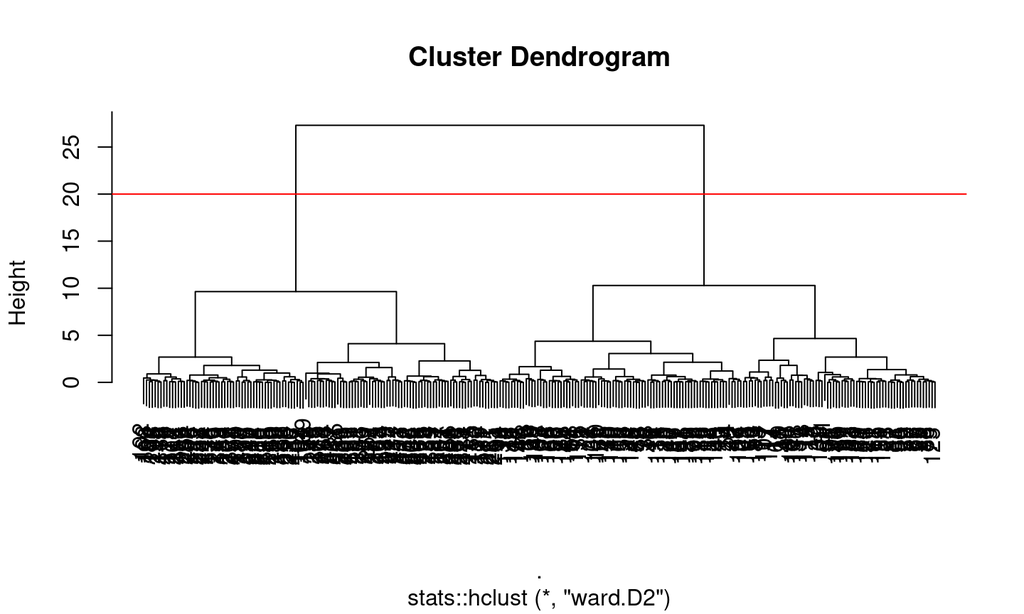

```
## integer(0)
```

## Hierarchical clustering result

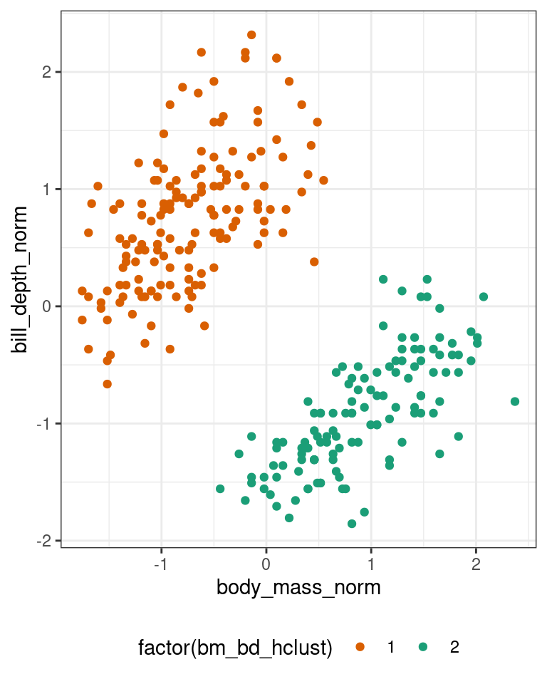

## Bagged clustering

Bootstrap aggregating (*b-agg-ed*) clustering approach

- first, k-means
  - randomly select a sample
  - calculate K-means
  - repeat on *many* samples
- then, hierarchical
  - execute hierarchical clustering on the centroids of the clusters generated in the previous step
- finally
  - select required number of clusters
  - assign object to closest centroid

Leisch, F., 1999. Bagged clustering.

## e1071::bclust

```r
penguins_bclust_result <-
  penguins_norm %>%
  dplyr::select(body_mass_norm, bill_depth_norm) %>%
  e1071::bclust(
    hclust.method = "ward.D2",
    resample = TRUE
  )

penguins_bm_bd_bclust <-
  penguins_norm %>%
  tibble::add_column(
    bm_bd_bclust = e1071::clusters.bclust(
      penguins_bclust_result,
      2
    )
  )
```

## Bagged clustering result

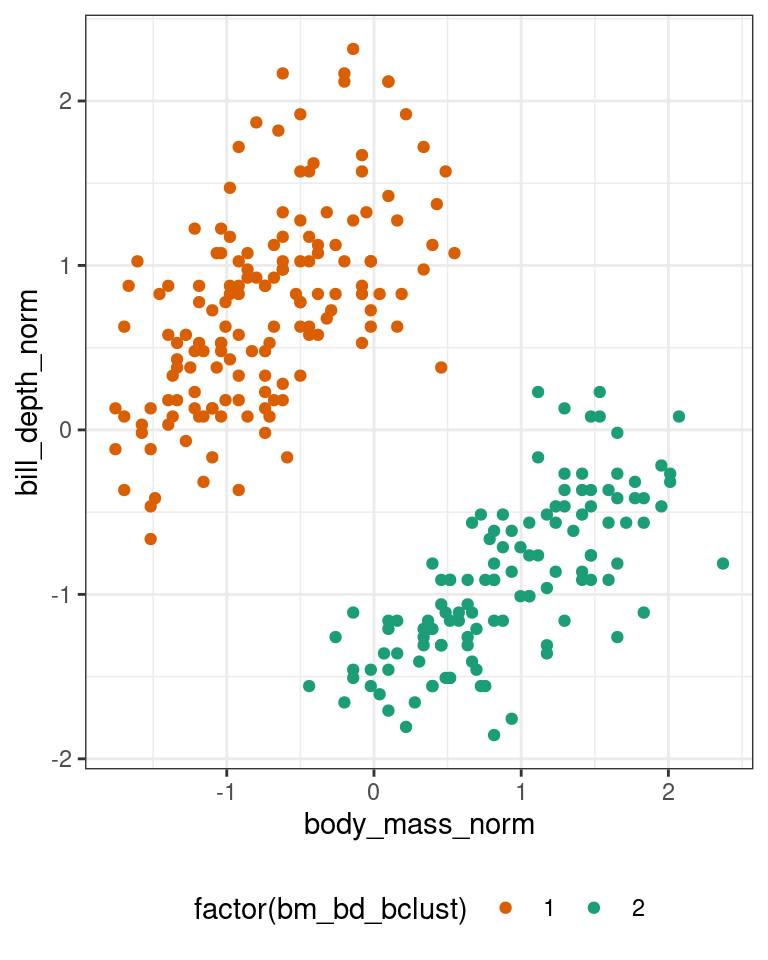

## Density based clustering

Density-based spatial clustering of applications with noise (DBSCAN)

- start from a random unclustered point
  - proceed by aggregating its neighbours to the same cluster
    - as long as they are within a certain distance `eps`
- once no more objects can be added
  - select another random point
  - and start aggregating again to a new cluster

**Limitation**: selection of `eps`

Ester, M., Kriegel, H.P., Sander, J. and Xu, X., 1996, August. Density-based spatial clustering of applications with noise. In Int. Conf. Knowledge Discovery and Data Mining (Vol. 240, p. 6).

## dbscan::dbscan

```r
penguins_dbscan_result <-
  penguins_norm %>%
  dplyr::select(body_mass_norm, bill_depth_norm) %>%
  dbscan::dbscan(
    eps = 1,
    minPts = 5
  )

penguins_bm_bd_dbscan <-
  penguins_norm %>%
  tibble::add_column(
    bm_bd_dbscan =
      penguins_dbscan_result %$%
      cluster
  )
```

## DBSCAN result

Using: `dbscan(eps = 1, minPts = 5)`

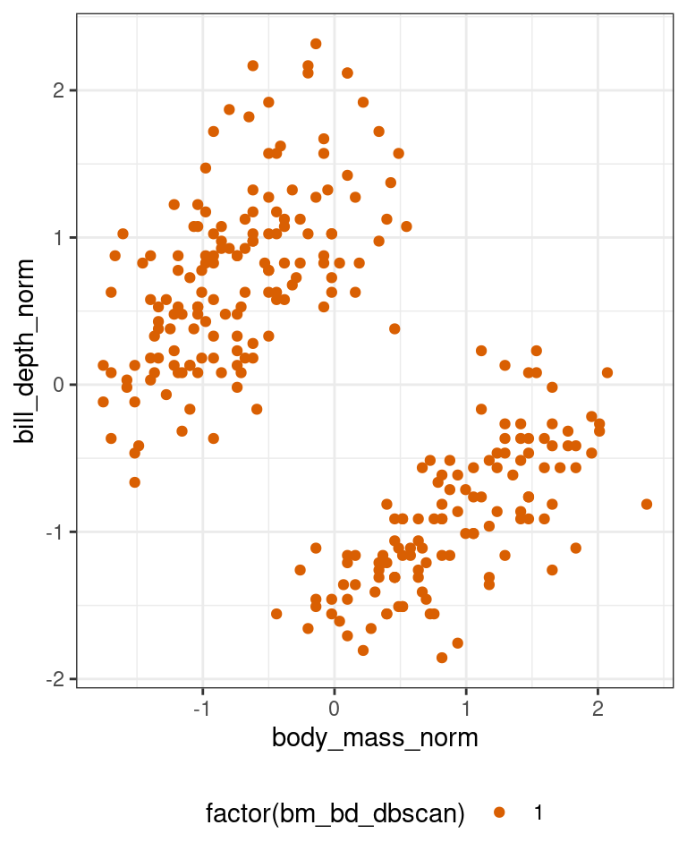

## DBSCAN result

Using: `dbscan(eps = 0.5, minPts = 5)`

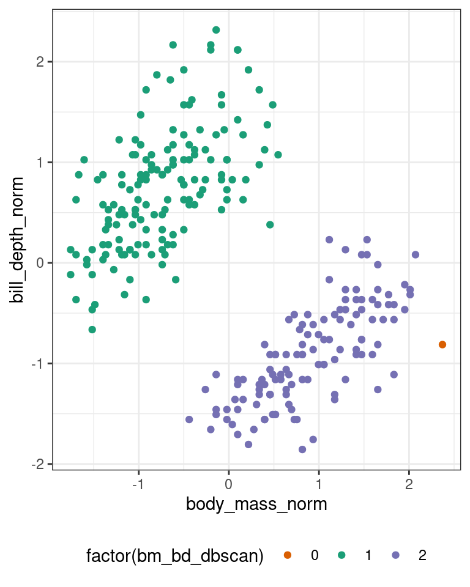

## DBSCAN result

Using: `dbscan(eps = 0.1, minPts = 5)`

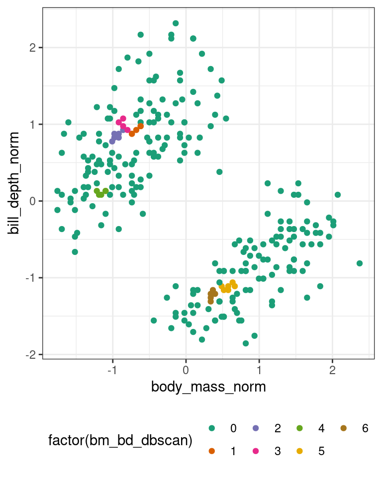

## Not alwasy that easy…

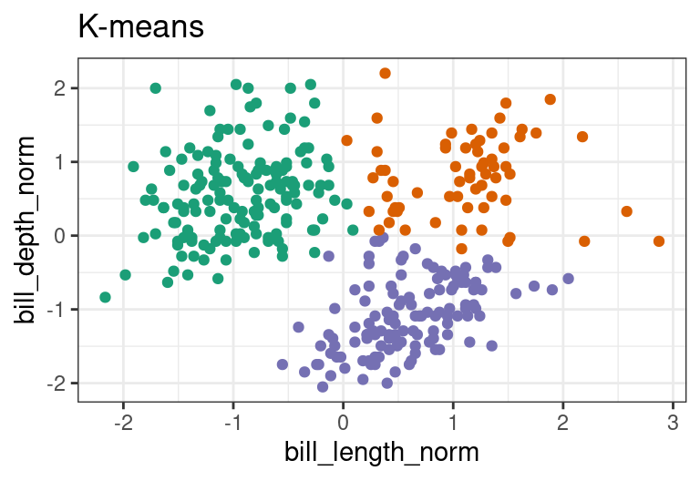

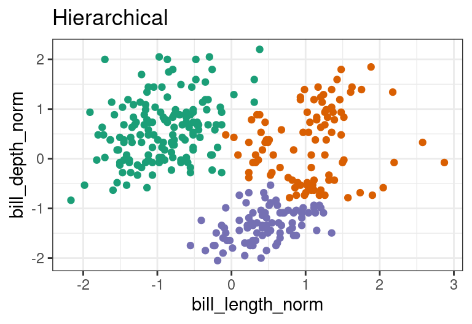

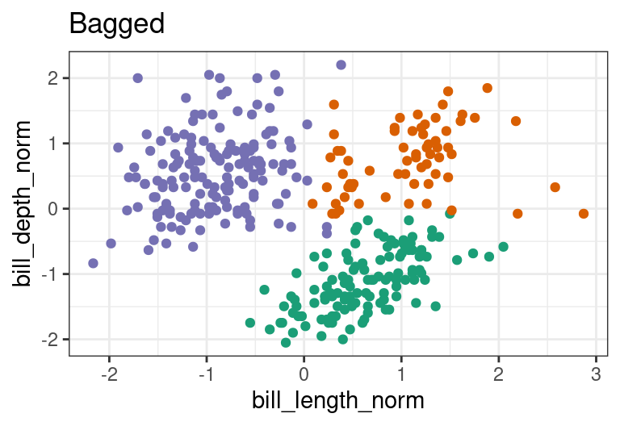

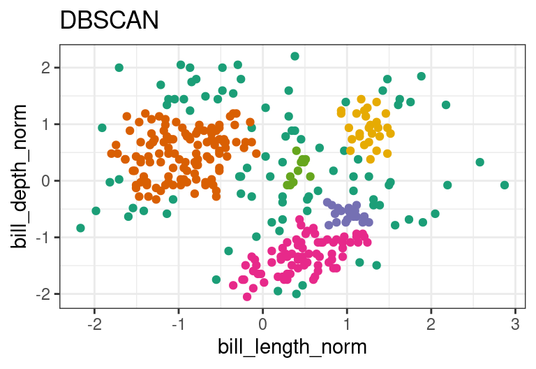

## Summary

Hierarchical and density-based clustering

- Hierarchical
- Mixed
- Density-based

**Next**: Practical session

- Geodemographic classification